# NFL Elo Data Analysis

Keshab Bashyal

2024-10-20

# 1. Introduction

This project analyzes NFL Elo data using R. The dataset contains information on various NFL games, including Elo ratings, team scores, and other metrics. The aim is to clean the data, handle missing values, and visualize key variables.

# 2. Load Required Libraries

```r
# Loading required libraries
library(tidyverse)  # For data wrangling and visualization
```

```r
library(lubridate)  # For date manipulation
library(ggplot2)    # For visualization
library(writexl)    # For saving the cleaned data
```

# 3. Load the Dataset

```
## # A tibble: 6 × 30
##    date season neutral playoff team1 team2 elo1_pre elo2_pre elo_prob1 elo_prob2
##   <dbl>  <dbl>   <dbl> <lgl>   <chr> <chr> <chr>       <dbl>     <dbl>     <dbl>
## 1 44084   2020       0 NA      KC    Hous… 1664.84…    1528.     0.762     0.238
## 2 44087   2020       0 NA      MIN   GB    1571.14…    1582.     0.577     0.423
## 3 44087   2020       0 NA      BUF   NYJ   1511.35…    1458.     0.664     0.336
## 4 44087   2020       0 NA      ATL   SEA   1534.51…    1547.     0.575     0.425
## 5 44087   2020       0 NA      JAX   IND   1438.50…    1483.     0.530     0.470
## 6 44087   2020       0 NA      BAL   CLE   1638.43…    1441.     0.820     0.180
## # ℹ 20 more variables: elo1_post <dbl>, elo2_post <chr>, qbelo1_pre <dbl>,
## #   qbelo2_pre <dbl>, qb1 <chr>, qb2 <chr>, qb1_value_pre <dbl>,
## #   qb2_value_pre <chr>, qb1_adj <chr>, qb2_adj <dbl>, qbelo_prob1 <dbl>,
## #   qbelo_prob2 <dbl>, qb1_game_value <dbl>, qb2_game_value <dbl>,
## #   qb1_value_post <dbl>, qb2_value_post <dbl>, qbelo1_post <dbl>,
## #   qbelo2_post <dbl>, score1 <dbl>, score2 <dbl>
```

# 4. Data Cleaning

## 4.1 Step 1: Convert the date Column to a Proper Date Format

In the first step of the data cleaning process, we converted the date column from Excel serial format to a standard date format, ensuring consistency and easier manipulation in future analysis.

```
## [1] "Before cleaning - Date column:"
```

```
## [1] 44084 44087 44087 44087 44087 44087
```

```
## [1] "After cleaning - Date column:"
```

```
## [1] "2020-09-10" "2020-09-13" "2020-09-13" "2020-09-13" "2020-09-13"
## [6] "2020-09-13"
```

# 4.2 Step 2: Fix Data Types in Columns

To ensure proper analysis, we converted key columns (such as Elo ratings and quarterback Elo scores) to numeric types, allowing for mathematical operations and visualizations.

```
## [1] "Before cleaning - Data types:"
```

```
## tibble [106 × 30] (S3: tbl_df/tbl/data.frame)
##  $ date          : num [1:106] 44084 44087 44087 44087 44087 ...
##  $ season        : num [1:106] 2020 2020 2020 2020 2020 2020 2020 2 2020 2020 ...
##  $ neutral       : num [1:106] 0 0 0 0 0 0 0 0 0 99 ...
##  $ playoff       : logi [1:106] NA NA NA NA NA NA ...
##  $ team1         : chr [1:106] "KC" "MIN" "BUF" "ATL" ...
##  $ team2         : chr [1:106] "Houston" "GB" "NYJ" "SEA" ...
##  $ elo1_pre      : chr [1:106] "1664.8472507562999" "1571.1400267578999" "1511.3545907602099" "1534.51556573532" ...
##  $ elo2_pre      : num [1:106] 1528 1582 1458 1547 1483 ...
##  $ elo_prob1     : num [1:106] 0.762 0.577 0.664 0.575 0.53 ...
##  $ elo_prob2     : num [1:106] 0.238 0.423 0.336 0.425 0.47 ...
##  $ elo1_post     : num [1:106] 1677 1544 1527 1503 1458 ...
##  $ elo2_post     : chr [1:106] "1516.11122943531" "1609.6782594501699" "1442.7692173709199" "1577.9998436159201" ...
##  $ qbelo1_pre    : num [1:106] 1651 1545 1533 1501 1392 ...
##  $ qbelo2_pre    : num [1:106] 1497 1555 1451 1544 1518 ...
```

[output cut: 16 more lines]

```
## [1] "After cleaning - Data types:"
```

```
## tibble [106 × 30] (S3: tbl_df/tbl/data.frame)
##  $ date          : Date[1:106], format: "2020-09-10" "2020-09-13" ...
##  $ season        : num [1:106] 2020 2020 2020 2020 2020 2020 2020 2 2020 2020 ...
##  $ neutral       : num [1:106] 0 0 0 0 0 0 0 0 0 99 ...
##  $ playoff       : logi [1:106] NA NA NA NA NA NA ...
##  $ team1         : chr [1:106] "KC" "MIN" "BUF" "ATL" ...
##  $ team2         : chr [1:106] "Houston" "GB" "NYJ" "SEA" ...
##  $ elo1_pre      : num [1:106] 1665 1571 1511 1535 1439 ...
##  $ elo2_pre      : num [1:106] 1528 1582 1458 1547 1483 ...
##  $ elo_prob1     : num [1:106] 0.762 0.577 0.664 0.575 0.53 ...
##  $ elo_prob2     : num [1:106] 0.238 0.423 0.336 0.425 0.47 ...
##  $ elo1_post     : num [1:106] 1677 1544 1527 1503 1458 ...
##  $ elo2_post     : num [1:106] 1516 1610 1443 1578 1463 ...
##  $ qbelo1_pre    : num [1:106] 1651 1545 1533 1501 1392 ...
##  $ qbelo2_pre    : num [1:106] 1497 1555 1451 1544 1518 ...
```

[output cut: 16 more lines]

## 4.3 Step 3: Remove Unnecessary Columns (neutral, playoffs)

We removed the columns neutral and playoffs as they were deemed unnecessary for this analysis.

```
##  [1] "date"           "season"         "team1"          "team2"
##  [5] "elo1_pre"       "elo2_pre"       "elo_prob1"      "elo_prob2"
##  [9] "elo1_post"      "elo2_post"      "qbelo1_pre"     "qbelo2_pre"
## [13] "qb1"            "qb2"            "qb1_value_pre"  "qb2_value_pre"
## [17] "qb1_adj"        "qb2_adj"        "qbelo_prob1"    "qbelo_prob2"
## [21] "qb1_game_value" "qb2_game_value" "qb1_value_post" "qb2_value_post"
## [25] "qbelo1_post"    "qbelo2_post"    "score1"         "score2"
```

```
## [1] "Rows remaining after cleaning: 87"
```

## 4.5 Step 5: Impute Missing Values in Specific Columns

```
## [1] "Updated 'season' and 'elo1_pre' columns after imputing missing values:"
```

```
## # A tibble: 6 × 2
##   season elo1_pre
##    <dbl>    <dbl>
## 1   2020    1665.
## 2   2020    1571.
## 3   2020    1511.
## 4   2020    1535.
## 5   2020    1439.
## 6   2020    1638.
```

# 4.6 Step 6 Save Cleaned Data

After completing the data cleaning steps, we saved the cleaned dataset to an Excel file for further use.

```r
# Save the cleaned data to an Excel file
writexl::write_xlsx(nfl_data_clean, "cleaned_data.xlsx")
```

# 5 Summary of the Data Cleaning

In this project, we conducted several data cleaning steps to prepare the NFL Elo dataset for further analysis. These steps included:

- Date Conversion:
  - The date column was converted to a proper Date format.
- Fixing Data Types:
  - Key numeric columns (e.g., Elo ratings and quarterback ratings) were converted to numeric types.
- Removing Unnecessary Columns:
  - We removed irrelevant columns such as neutral and playoffs.
- Handling Missing and Zero Values:
  - Rows with missing values (NA), zeros, or empty values were removed.
- Handling Inconsistent Data:
  - We corrected inconsistent values in the season and elo1_pre columns.
- Rows Removed
  - A total of 19 rows containing invalid or incomplete data were removed during the cleaning process

# Visualization

## 6.1 Histogram for Numeric Variables

We visualize the distribution of each numeric variable using histograms, presented in a 1x2 layout.

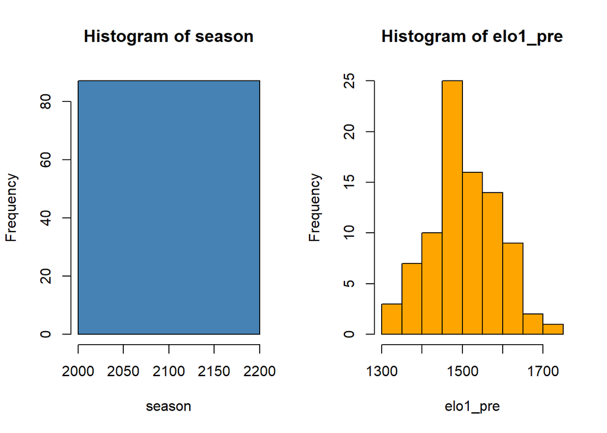

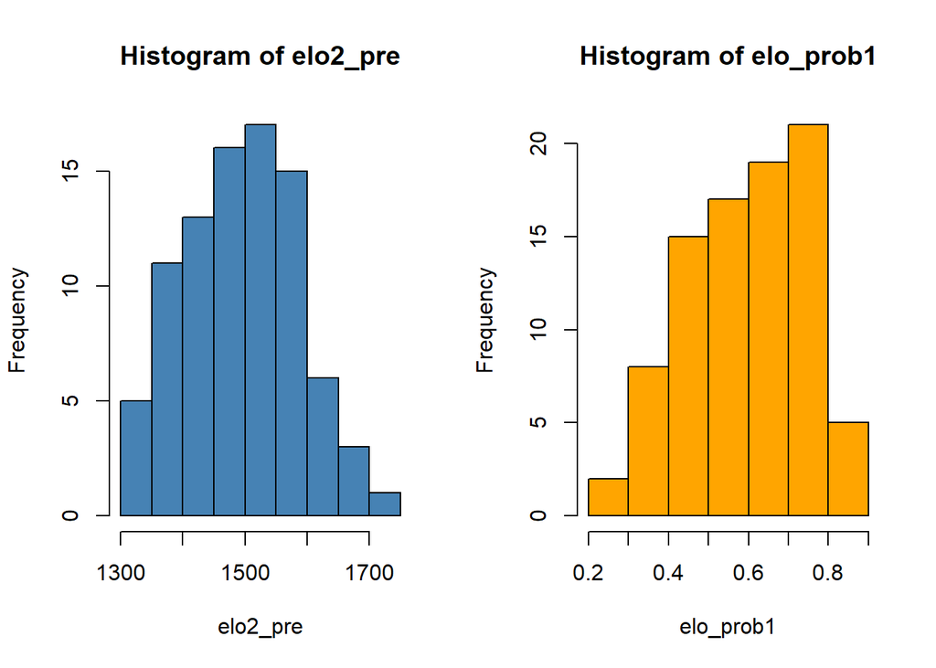

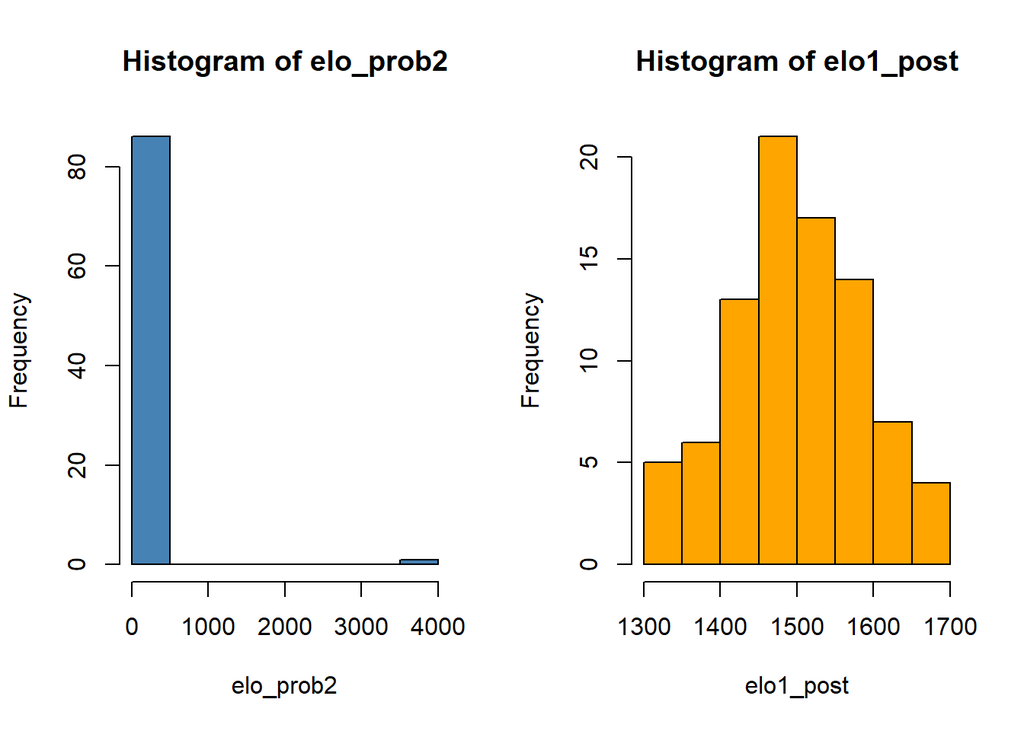

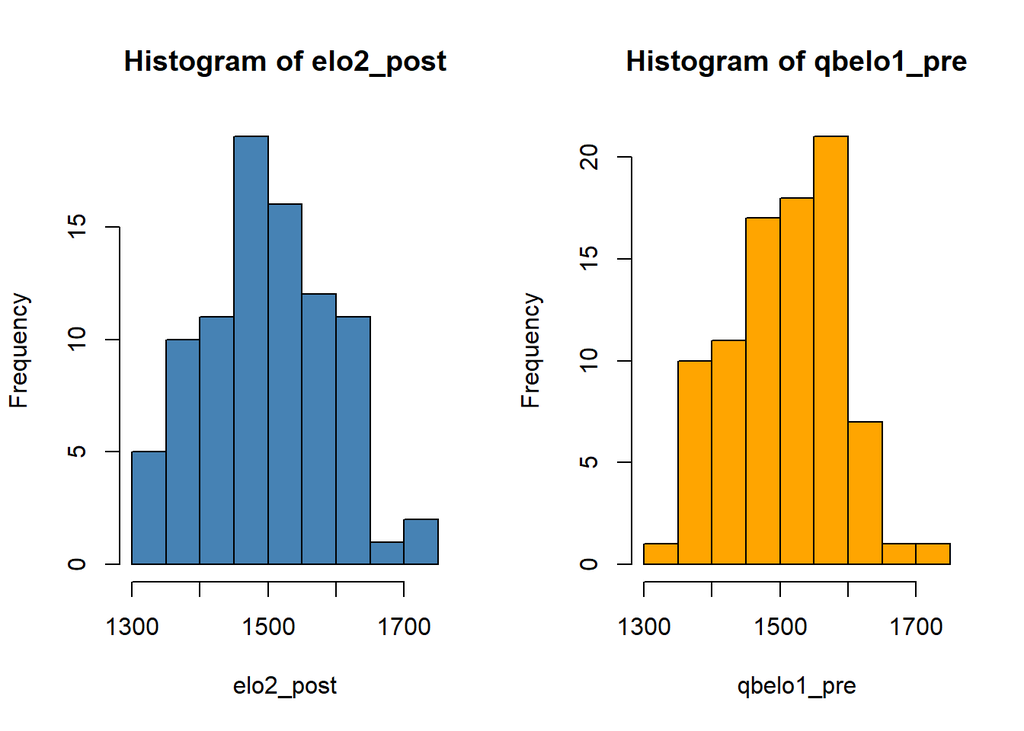

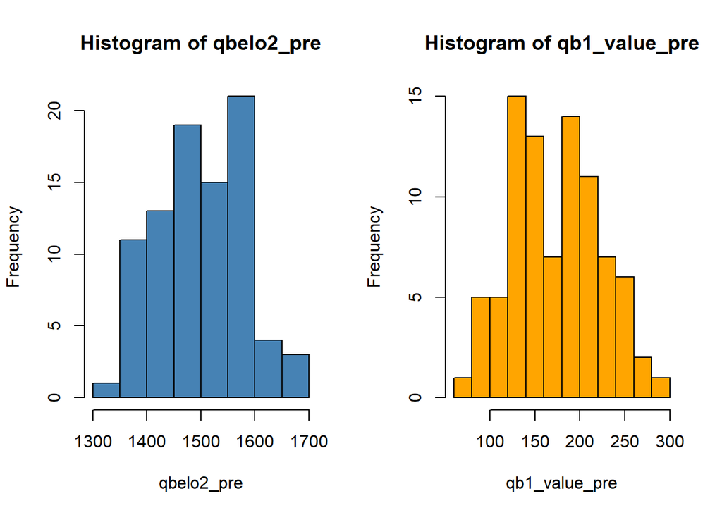

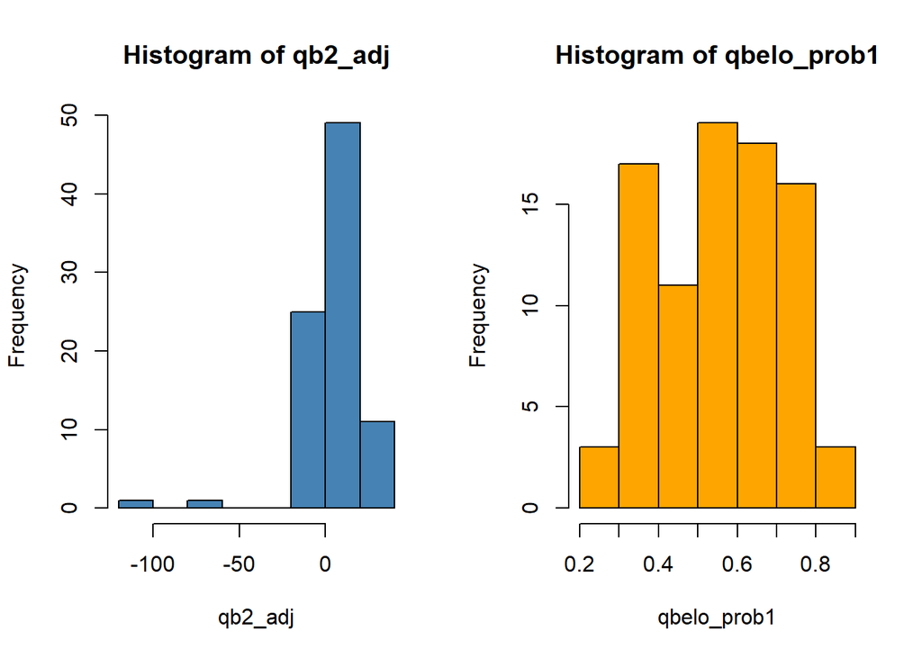

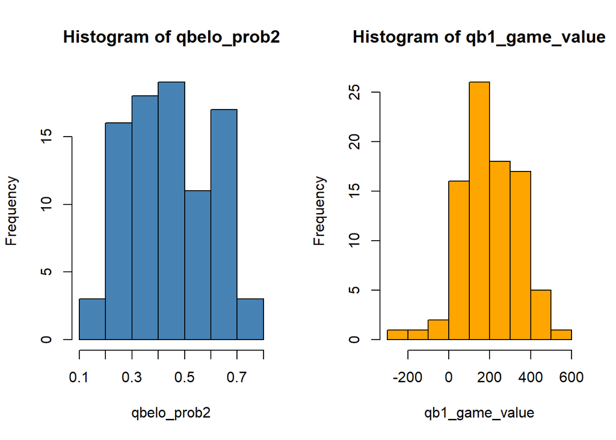

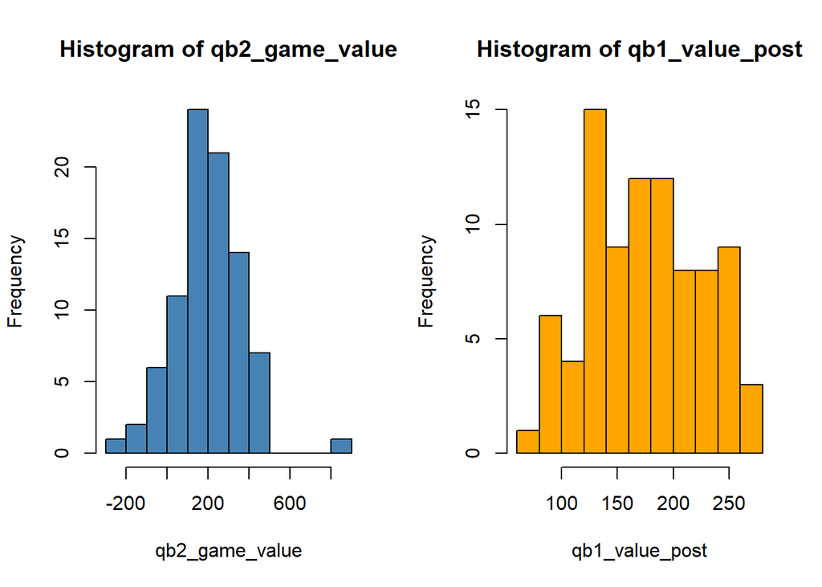

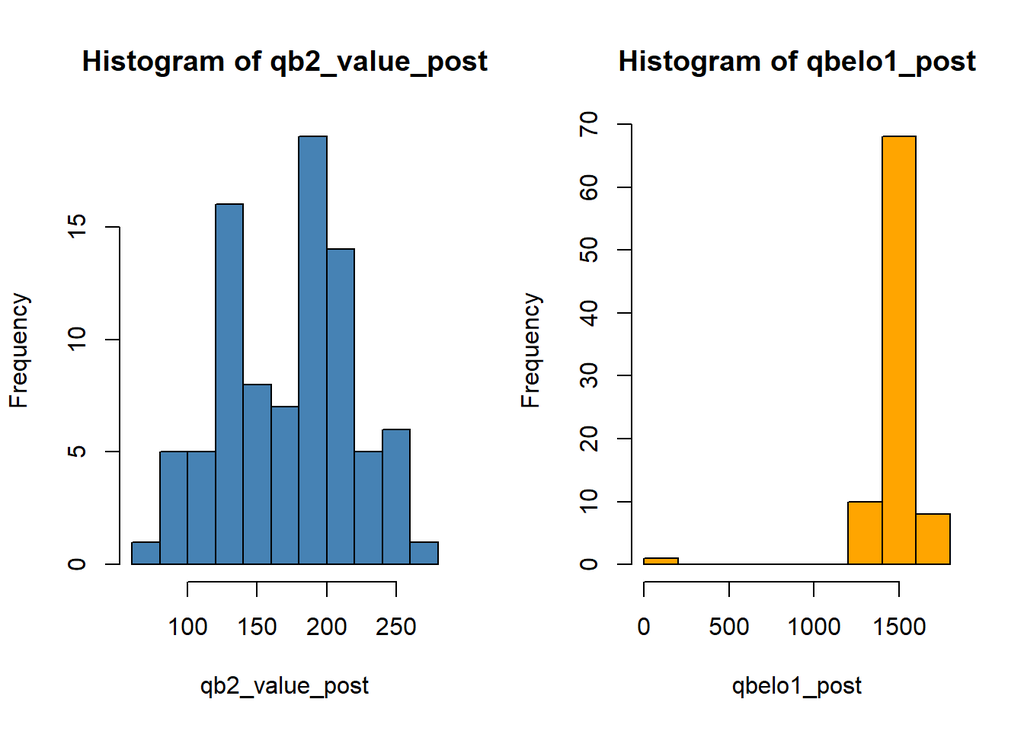

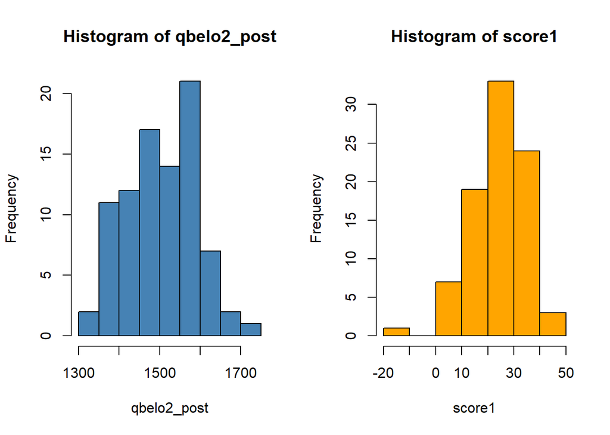

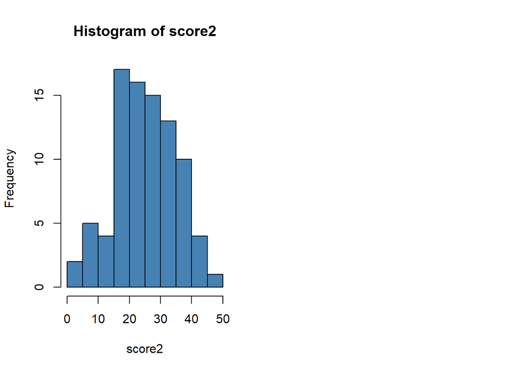

```r
# Select numeric columns
numeric_cols <- nfl_data_clean %>% select(where(is.numeric)) %>% colnames()

# Loop through the numeric columns and create histograms in a 1x2 layout
for (i in seq(1, length(numeric_cols), by = 2)) {
  col1 <- numeric_cols[i]
  col2 <- ifelse(i+1 <= length(numeric_cols), numeric_cols[i+1], NA)  # Get the second column for the layout

  # 1x2 layout for histograms
  par(mfrow = c(1, 2))

  # Plot the first histogram
  hist(nfl_data_clean[[col1]], main = paste("Histogram of", col1),
       xlab = col1, col = "steelblue", border = "black")

  # Plot the second histogram if it exists
  if (!is.na(col2)) {
    hist(nfl_data_clean[[col2]], main = paste("Histogram of", col2),
         xlab = col2, col = "orange", border = "black")
  }

  # Reset plotting layout for the next iteration
  par(mfrow = c(1, 1))
}
```

## 6.2 Box Plot for Numeric Variables We use box plots to visualize the spread and outliers for each numeric variable, also arranged in a 1x2 layout.

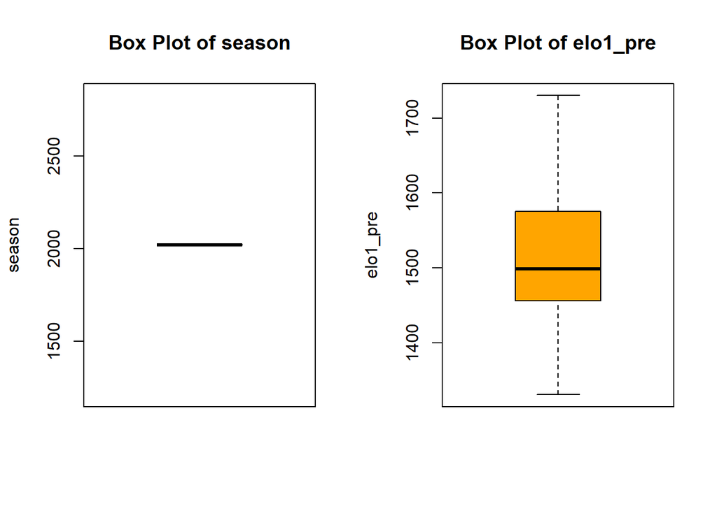

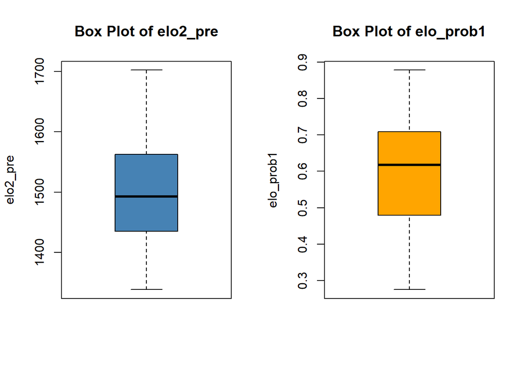

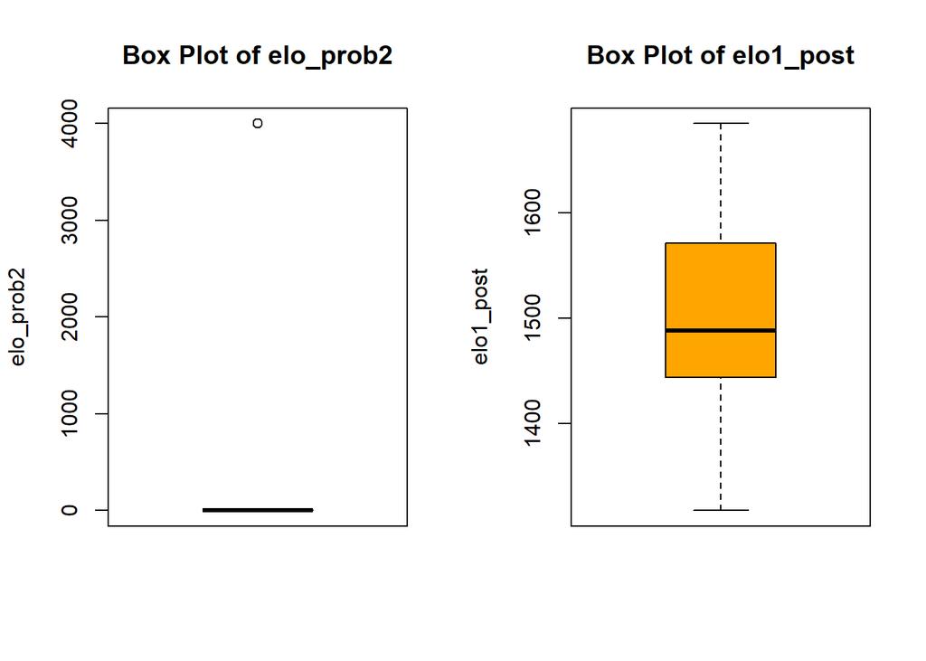

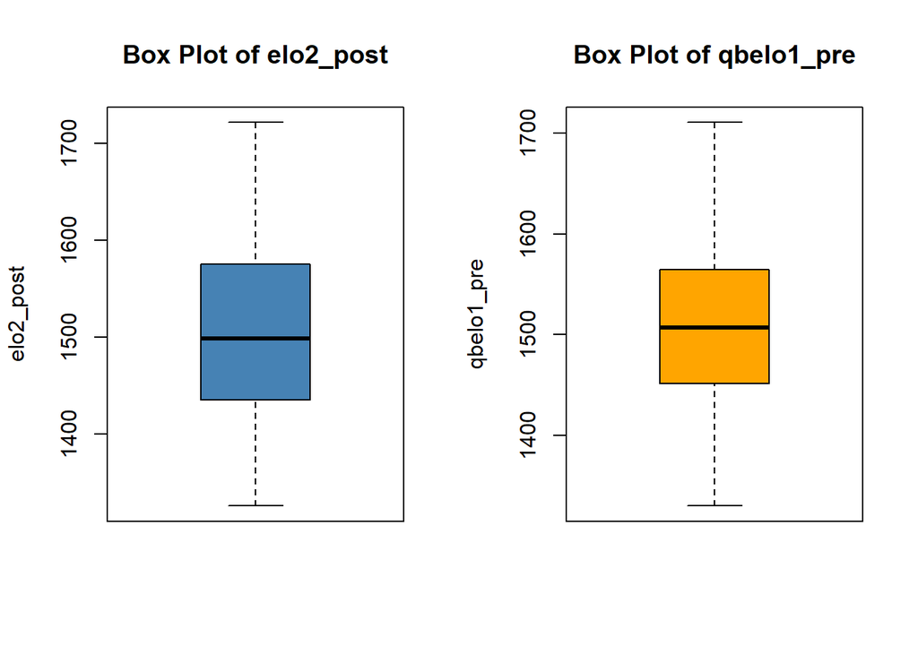

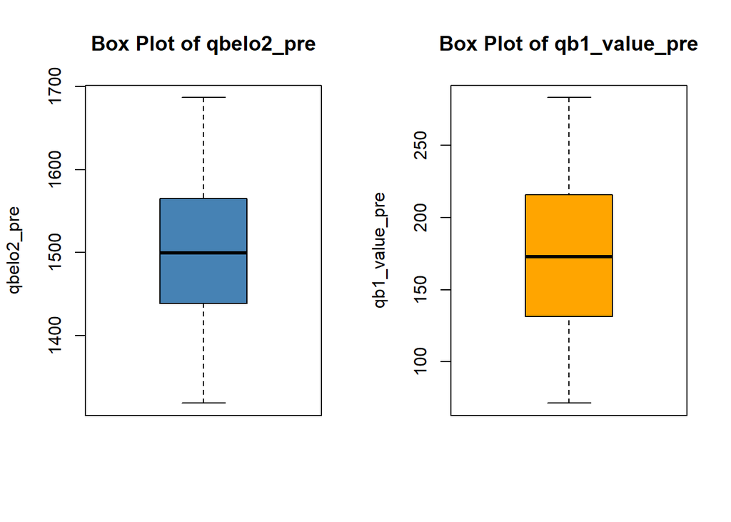

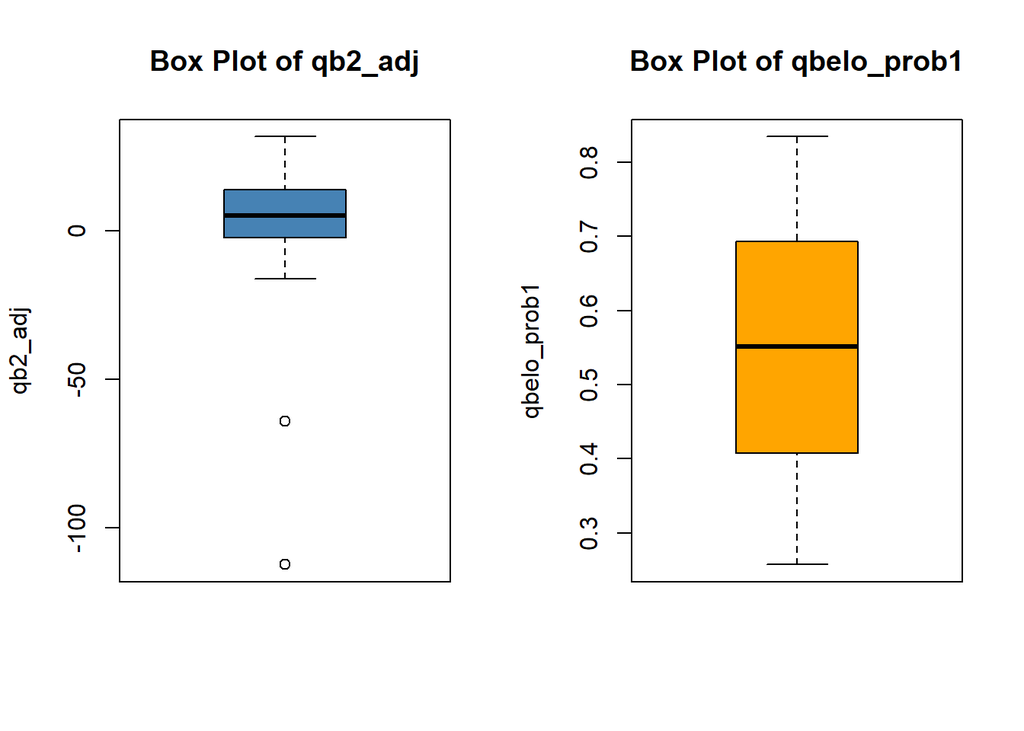

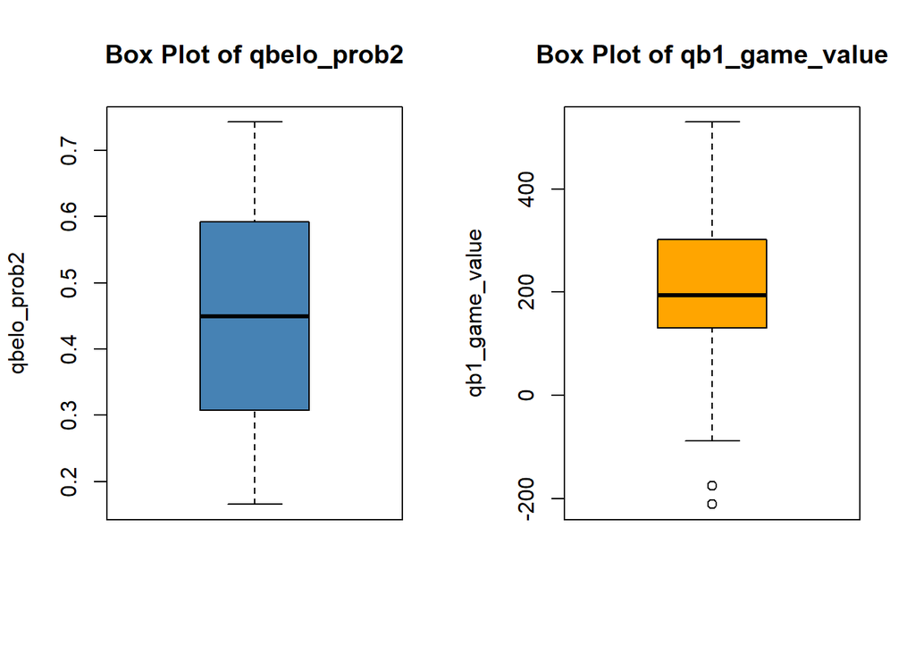

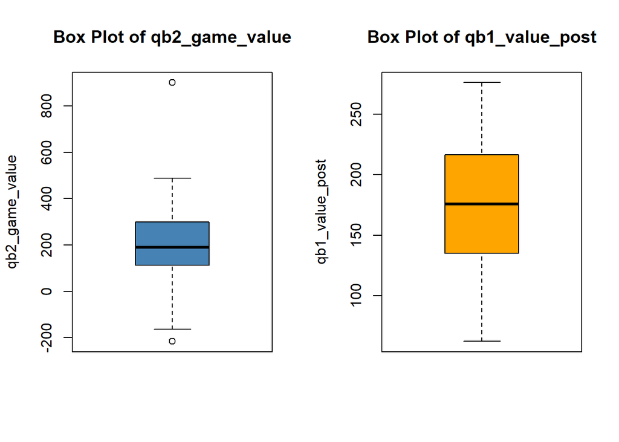

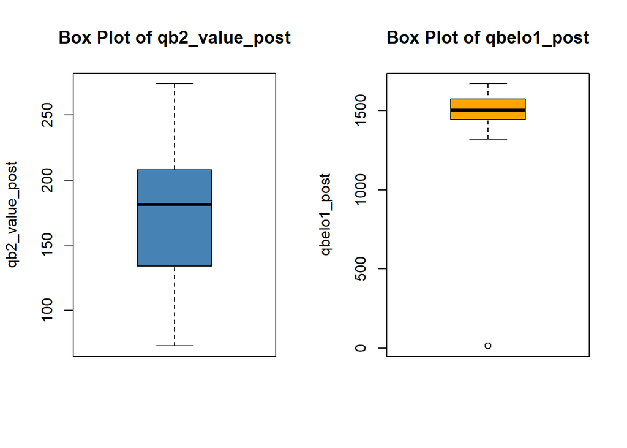

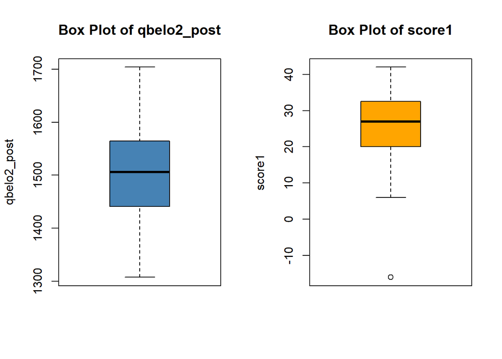

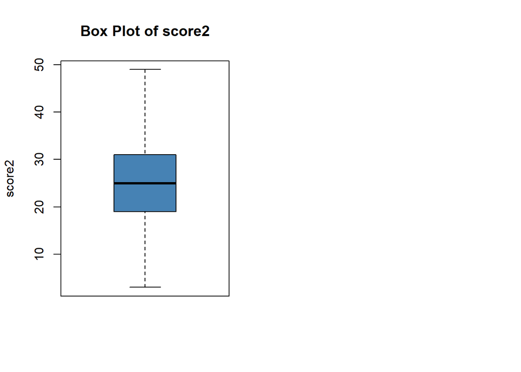

```r
# Loop through the numeric columns and create box plots in a 1x2 layout
for (i in seq(1, length(numeric_cols), by = 2)) {
  col1 <- numeric_cols[i]
  col2 <- ifelse(i+1 <= length(numeric_cols), numeric_cols[i+1], NA)  # Get the second column for the layout

  # 1x2 layout for box plots
  par(mfrow = c(1, 2))

  # Plot the first box plot
  boxplot(nfl_data_clean[[col1]], main = paste("Box Plot of", col1),
          ylab = col1, col = "steelblue", border = "black")

  # Plot the second box plot if it exists
  if (!is.na(col2)) {
    boxplot(nfl_data_clean[[col2]], main = paste("Box Plot of", col2),
            ylab = col2, col = "orange", border = "black")
  }

  # Reset plotting layout for the next iteration
  par(mfrow = c(1, 1))
}
```

## 6.3 Scatter Plot

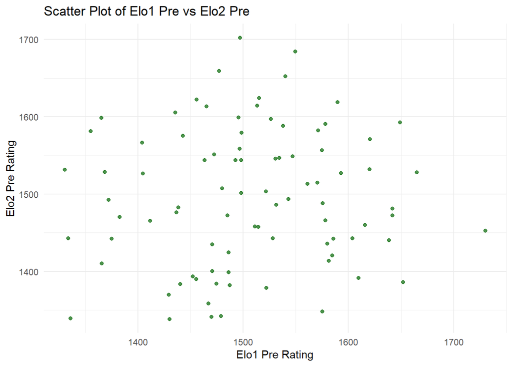

```r
# Scatter plot to visualize the relationship between elo1_pre and elo2_pre
ggplot(nfl_data_clean, aes(x = elo1_pre, y = elo2_pre)) +
  geom_point(color = "darkgreen", alpha = 0.7) +
  labs(title = "Scatter Plot of Elo1 Pre vs Elo2 Pre", x = "Elo1 Pre Rating", y = "Elo2 Pre Rating") +
  theme_minimal()
```

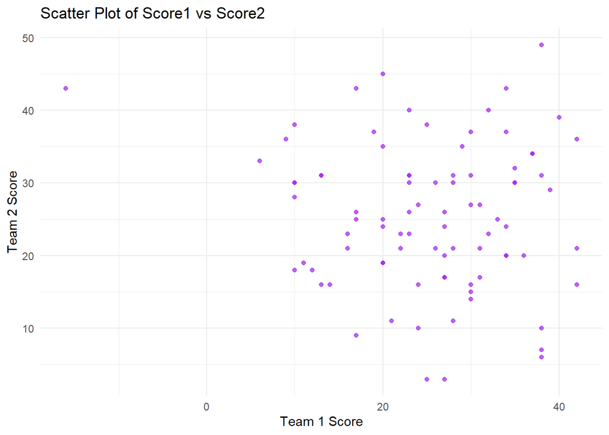

```r
# Scatter plot for team scores
ggplot(nfl_data_clean, aes(x = score1, y = score2)) +
  geom_point(color = "purple", alpha = 0.7) +
  labs(title = "Scatter Plot of Score1 vs Score2", x = "Team 1 Score", y = "Team 2 Score") +
  theme_minimal()
```